# Prueba Técnica Profesional III Departamento de Datos no Estructurados: Prueba Imagenes con OCR.

### Tabla de Contenido.

Nota: Puede dar click en la sección que escoja.

- Metodologia CRISP-DM
- Comprension Empresarial.
- Comprensión de los Datos
  - Importación de Librerias y de Datos.
  - Lectura de la primeras Imagenes de ejemplo
  - Extracción de texto
- Preparación de Datos
- Modelado: Descripción de la Estrategia de Análisis
  - Particion de los Datos
  - Regresion Logistica
  - Naive Bayes
  - K vecinos mas cercanos
  - Random Forest Classifier
- Evaluacion y comparacion
  - Clasificar imagenes y cargarlas a la carpeta correspondiente.

### Metodologia CRISP-DM

El proceso estándar de la industria cruzada para la minería de datos (CRISP-DM) es un modelo de proceso que sirve como base para un proceso de ciencia de datos. Tiene seis fases secuenciales:

**Comprensión empresarial**: ¿Qué necesita la empresa?

**Comprensión de datos**: ¿Qué datos tenemos/necesitamos? ¿Está limpio?

**Preparación de datos**: ¿Cómo organizamos los datos para el modelado?

**Modelado** – ¿Qué técnicas de modelado debemos aplicar?

**Evaluación**: ¿Qué modelo cumple mejor con los objetivos comerciales?

**Implementación**: ¿cómo acceden las partes interesadas a los resultados?

[figure not shown]

### Comprensión Empresarial.

Según Gartner, en este momento, los datos no estructurados conforman el 80-90% del total de los datos que manejan las compañías. Dentro de ellos, las imágenes de documentos ocupan un lugar importante. Cada año se hace más evidente la necesidad de convertir los datos contenidos en estas imágenes en información útil que pueda ser analizada en bases de datos.

Dentro de los primeros pasos para lograr este objetivo se encuentra, por supuesto, el identificar qué imágenes guardan contenido y cuáles pueden desecharse, lo que se traducirá en menores costos de almacenamiento, procesamiento de archivos y recursos humanos.

### Comprensión de los Datos.

Se tienen dos conjuntos de bases de datos, con archivos escaneados. La primera carpera se llama “blanco”, y contiene documentos escaneados sin nada de texto, o con texto para nada relevante, como marcas de agua o pie de páginas, la otra carpeta se llama “documentos” y contiene información relevante, texto, datos, y demás.

#### Importación de Librerias y de Datos.

Las librerias mas importantes que se utilizan son *cv2*, que hace referencia a los elementos de la libreria OpenCV, que siginifica *open computer vision*, y es una biblioteca libre de visión artificial originalmente desarrollada por Intel; y la libreria *pytesseract*, es una herramienta de reconocimiento óptico de caracteres (OCR) para Python. Es decir, reconocerá y “leerá” el texto incrustado en las imágenes. Python-tesseract es un contenedor para el motor Tesseract-OCR de Google.

Se puede descargar el motor de tesseract en el siguiente [link](https://github.com/UB-Mannheim/tesseract/wiki).

Se puede encontrar instrucciones de instalacion en el siguiente [link](https://stackoverflow.com/questions/50951955/pytesseract-tesseractnotfound-error-tesseract-is-not-installed-or-its-not-i)

```python
# importar las librerias que se necesitan.
import cv2
import pytesseract
import matplotlib.pyplot as plt
import matplotlib.image as mpimg
import seaborn as sns

pytesseract.pytesseract.tesseract_cmd = r'C:\Program Files\Tesseract-OCR\tesseract.exe'

import os
import glob
import pandas as pd
import numpy as np
```

Python version 3.7.

Version de las librerias

- cv2 3.4.2
- pytesseract 0.3.10
- matplotlib 3.5.1
- seaborn 0.11.2
- pandas 1.3.5
- numpy 1.21.5

```python
# directorio donde se encuentran todas los documentos escaneados

files_blanco = glob.glob(".\Blanco\*.png") # documentos en blanco
files_texto = glob.glob(".\Documentos\*.png") # documentos con contenido
file_count_b = len(files_blanco)
file_count_t = len(files_texto)
```

```python
# funcion para tratar las imagenes

def image_process(img, n1, n2):
    gray = cv2.cvtColor(img, cv2.COLOR_BGR2GRAY) # transformar las imagenes a escala de grises

    ret, thresh1 = cv2.threshold(gray, 0, 255, cv2.THRESH_OTSU | cv2.THRESH_BINARY_INV) # crear un recuadro para el recorte de la imagen

    # cv2.threshold() tiene 4 parámetros, el primer parámetro es la imagen con cambio de espacio de color,
    # seguido del valor de umbral mínimo, el valor de umbral máximo y el tipo de umbral que debe aplicarse.
    rect_kernel = cv2.getStructuringElement(cv2.MORPH_RECT, (n1, n2)) #

    # cv2.getStructuringElement() se usa para definir un elemento estructural como elíptico, circular, rectangular, etc.
    dilation = cv2.dilate(thresh1, rect_kernel, iterations = 1)

    # cv2.findContours() se utiliza para buscar contornos en la imagen dilatada.
    _,contours, hierarchy = cv2.findContours(dilation, cv2.RETR_EXTERNAL,
                                                 cv2.CHAIN_APPROX_NONE)

    image_copy = img.copy()

    return image_copy, contours, hierarchy
```

```python
# funcion para extraer el texto de las imagenes previamente tratadas
def get_text(image, contours):
    ll = []

    for cnt in contours:
        # coordenada X, coordenada Y, ancho, alto
        x, y, w, h = cv2.boundingRect(cnt)

        # Dibujar un rectángulo en la imagen copiada
        rect = cv2.rectangle(image, (x, y), (x + w, y + h), (0, 255, 0), 2)

        # Recortar el bloque de texto para dar entrada a OCR
        cropped = image[y:y + h, x:x + w]


        # Aplicar OCR en la imagen recortada
        text = pytesseract.image_to_string(cropped)

        # print(text)
        ll.append(text)
        # Appending the text into file
        # file.write(text)
        # file.write("\n")

        # # Close the file
        # file.close
    return ll
```

**Lectura de la primeras Imagenes de ejemplo**

Se puede observar en la siguiente imagen, como se presentan algunos documentos escaneados.

[figure not shown]

```python
# leer primera imagen
img1 = cv2.imread(r"C:\Users\MANUEL ALEJANDRO\Documentos\Prueba_conocimientos_davivienda\Ejercicio_1_Imagenes\Datasets\Documentos\page-19.png")
img2 = cv2.imread(r"C:\Users\MANUEL ALEJANDRO\Documentos\Prueba_conocimientos_davivienda\Ejercicio_1_Imagenes\Datasets\Documentos\page-119.png")

fig, ax = plt.subplot_mosaic([["p1", "p2"]],figsize=(20, 20))
ax["p1"].imshow(img1)
ax["p1"].set_title("img1", size = 20)
ax["p1"].axis('off')
ax["p2"].imshow(img2)
ax["p2"].set_title("img2", size = 20)
ax["p2"].axis('off')
plt.show()
```

**Extracción de texto**

Y en la siguiente celda, se puede observar que el texto se extrea de una forma correcta.

```python
im1, c1, _ = image_process(img1, 18, 18)
result1 = get_text(image=im1, contours=c1)

im2, c2, _ = image_process(img2, 18, 18)
result2 = get_text(image=im2, contours=c2)
print("img1: ",*result1[::-1], sep= "\n")
```

```
img1:
A DETAILED ANALYSIS OF THE


COMPONENT OBJECT MODEL


Thesis approved:


Dr. M. H. Samadzadeh


Thesis Advisor


Dr. Blayne E. Mayfield


Dr. Nohpill Park


Dr. Gordon Emslie


Dean of the Graduate College
```

```python
print("img2: ",*result2[::-1], sep= "\n")
```

```
img2:
DISCLAIMER

The information contained herein is for informational purposes only, and is subject to
change without notice. While every precaution has been taken in the preparation of this
document, it may contain technical inaccuracies, omissions and typographical errors, and
AMD is under no obligation to update or otherwise correct this information. Advanced Mi-
cro Devices, Inc. makes no representations or warranties with respect to the accuracy or
completeness of the contents of this document, and assumes no liability of any kind, in-
cluding the implied warranties of noninfringement, merchantability or fitness for particular
purposes, with respect to the operation or use of AMD hardware, software or other prod-
ucts described herein. No license, including implied or arising by estoppel, to any intellec-
tual property rights is granted by this document. Terms and limitations applicable to the
purchase or use of AMD's products are as set forth in a signed agreement between the
parties or in AMD's Standard Terms and Conditions of Sale.


© 2015 Advanced Micro Devices, Inc. All rights reserved. AMD, the AMD Arrow logo,
AMD Accelerated Parallel Processing, the AMD Accelerated Parallel Processing logo, and
combinations thereof are trademarks of Advanced Micro Devices, Inc. OpenCL and the
OpenCL logo are trademarks of Apple Inc. used by permission by Khronos. Other names.
are for informational purposes only and may be trademarks of their respective owners.


AMD's products are not designed, intended, authorized or warranted for use as compo-
nents in systems intended for surgical implant into the body, or in other applications

intended to support or sustain life, or in any other application in which the failure of AMD’s
product could create a situation where personal injury, death, or severe property or envi-

ronmental damage may occur. AMD reserves the right to discontinue or make changes to
its products at any time without notice.


AMD¢1

Advanced Micro Devices, Inc.
One AMD Place
P.O. Box 3453
Sunnyvale, CA 94088-3453
www.amd.com


For AMD Accelerated Parallel Processing:

URL: developer.amd.com/appsdk
Developing: developer.amd.com/
Forum: developer.amd.com/openciforum


URL:
Developing:
Forum:


ii
```

### Preparación de Datos.

Importar todas las imagenes, tanto las que estan en datos en blanco como las que tienen texto.

Los datos se importan en escala de grises, lo cual permite tener los datos en un formato bi dimensional de colores. Despues, gracias a la ayuda de la libreria Numpy, se cuenta la cantidad de pixeles oscuros o negros, y la cantidad de pixeles de color claro o blancos.

```python
image_list_blanco = []
black_blanco = []
white_blanco = []

for i in range(file_count_b):
    temp_im = cv2.imread(files_blanco[i], 0) # 0 es para importar datos en escala de grises, el texto en negro y el resto en blanco
    w =  np.sum(temp_im == 255)# pixeles blancos, de espacios en blanco
    b =  np.sum(temp_im == 0)# pixeles negros, del texto e imagenes
    image_list_blanco.append(temp_im)
    white_blanco.append(w)
    black_blanco.append(b)
```

```python
image_list_texto = []
black_texto = []
white_texto = []

for i in range(file_count_t):
    temp_im = cv2.imread(files_texto[i], 0) # 0 es para importar datos en escala de grises, el texto en negro y el resto en blanco
    w =  np.sum(temp_im == 255) # pixeles blancos, de espacios en blanco
    b =  np.sum(temp_im == 0) # pixeles negros, del texto e imagenes
    image_list_texto.append(temp_im)
    white_texto.append(w)
    black_texto.append(b)
```

Se puede observar una muestra de los archivos que se extraen de la carpeta de archivos en blanco.

```python
png_names_b = [names[9:-4] for names in files_blanco] # los nombres de los archivos
png_names_b[0:10]
```

```
['page-156',
 'page-157',
 'page-158',
 'page-159',
 'page-160',
 'page-161',
 'page-162',
 'page-163',
 'page-164',
 'page-165']
```

Se puede observar una muestra de los archivos que se extraen de la carpeta de archivos con contenido.

```python
png_names_t = [names[13:-4] for names in files_texto] # los nombres de los archivos
png_names_t[0:10]
```

```
['page-10',
 'page-107',
 'page-109',
 'page-11',
 'page-112',
 'page-113',
 'page-114',
 'page-115',
 'page-116',
 'page-117']
```

Se crean varios diccionarios, en los cuales se almacenaran los documentos en blanco y los documentos con contenido.

Las imagenes son almacenadas en formato de matriz.

```python
# diccionario con la matriz de las imagenes originales, y su nombre
dictionary_b = dict(zip(png_names_b, image_list_blanco))
dictionary_t = dict(zip(png_names_t, image_list_texto))

# diccionario con la contabilizacion de los pixeles oscuros o negros, de cada imagen
# de los archivos que estan en blanco y los que tienen contenido.
black_dict_t = pd.DataFrame(dict(zip(png_names_t, black_texto)), index = [0]).T.reset_index()
black_dict_b = pd.DataFrame(dict(zip(png_names_b, black_blanco)), index = [0]).T.reset_index()

# diccionario con la contabilizacion de los pixeles claros o blancos, de cada imagen
# de los archivos que estan en blanco y los que tienen contenido.
white_dict_b = pd.DataFrame(dict(zip(png_names_b, white_blanco)), index = [0]).T.reset_index()
white_dict_t = pd.DataFrame(dict(zip(png_names_t, white_texto)), index = [0]).T.reset_index()
```

```python
# se concatenan los pixeles oscuros y los claros, dependiendo de si son documentos en blanco o con contenido.
blank_docs =  pd.merge(black_dict_b, white_dict_b, on="index", suffixes=["_black", "_white"])
text_docs = pd.merge(black_dict_t, white_dict_t, on="index", suffixes=["_black", "_white"])
```

Se creara una variable binaria, con el nombre *texto*, y sera 0, si el documento esta clasificado como un documento en blanco, y 1 si el documento esta clasificado como un documento con contenido.

### Modelado: Descripción de la Estrategia de Análisis.

Todas las imágenes tienen un espectro colores en la escala RGB, conformada por tres matrices con valores numéricos, y dependiendo de los valores numéricos en esas tres matrices, es que se configura la forma de la imagen, y principalmente, se configura la coloración; se pueden extraer de ahí la cantidad de pixeles por los cuales está conformada una imagen. Estas imágenes se pueden pasar a una escala grises, en la cual la imagen quedara a blanco y negro. Al momento de pasar la imagen a escala de grises, se pasa de tener 3 matrices en la escala RGB (Rojo, verde, azul por sus iniciales en inglés), a 2 matrices, en la cual se configura una matriz para la coloración clara o la intensidad del color blanco, y otra para la intensidad del color negro.

Gracias a la ayuda de la librería numérica de Python “Numpy”, se puede contar la cantidad de pixeles de color oscuro, y la cantidad de pixeles claros.

**¿Cómo puede ayudar esto?**

Si los documentos que se escanean contienen texto principal, que no sean marcas de agua ni demás, al momento de pasar la imagen a escala de grises, ese texto serán pixeles con valores netamente negros, o con el valor 0, y los espacios en blanco serán representados por pixeles blancos, o con el valor 255. La hipótesis para entrenar el modelo es que los documentos escaneados que no tienen contenido, o que están en blanco, tienen menos pixeles, principalmente menos pixeles negros, a comparación de los documentos que tienen contenido. Al tener el recuento de la cantidad de pixeles, se puede entrenar un modelo clasificatorio, para que aprenda la diferencia entre documentos en blanco y documentos con contenido, gracias a la contabilización de los pixeles en las imágenes.

```python
# se crea una nueva variable con 0
blank_docs["texto"] =  0
blank_docs
```

|  | index | 0_black | 0_white | texto |
| --- | --- | --- | --- | --- |
| 0 | page-156 | 0 | 2267269 | 0 |
| 1 | page-157 | 0 | 75999 | 0 |
| 2 | page-158 | 0 | 17782 | 0 |
| 3 | page-159 | 0 | 4572755 | 0 |
| 4 | page-160 | 0 | 2042844 | 0 |
| ... | ... | ... | ... | ... |
| 142 | page-298 | 0 | 847908 | 0 |
| 143 | page-299 | 0 | 1494311 | 0 |
| 144 | page-300 | 0 | 16026 | 0 |
| 145 | page-301 | 0 | 25513 | 0 |
| 146 | page-302 | 5329 | 8161583 | 0 |

147 rows × 4 columns

```python
# se crea una nueva variable con 1
text_docs["texto"] = 1
text_docs
```

|  | index | 0_black | 0_white | texto |
| --- | --- | --- | --- | --- |
| 0 | page-10 | 21689 | 1751037 | 1 |
| 1 | page-107 | 18312 | 1805947 | 1 |
| 2 | page-109 | 33357 | 1627723 | 1 |
| 3 | page-11 | 32249 | 1632538 | 1 |
| 4 | page-112 | 5645 | 1973359 | 1 |
| ... | ... | ... | ... | ... |
| 95 | page-89 | 9676 | 1889344 | 1 |
| 96 | page-9 | 48253 | 1657757 | 1 |
| 97 | page-92 | 8703 | 1875174 | 1 |
| 98 | page-93 | 36835 | 1667108 | 1 |
| 99 | page-94 | 30686 | 1806496 | 1 |

100 rows × 4 columns

Se concatenan las dos bases, y se crea una unica base conteniendo tanto el conteo de los pixeles oscuros, como el de los pixeles claros, y llevara el nombre de *complete_df*

```python
complete_df = pd.concat([blank_docs, text_docs]).reset_index()
complete_df
```

|  | level_0 | index | 0_black | 0_white | texto |
| --- | --- | --- | --- | --- | --- |
| 0 | 0 | page-156 | 0 | 2267269 | 0 |
| 1 | 1 | page-157 | 0 | 75999 | 0 |
| 2 | 2 | page-158 | 0 | 17782 | 0 |
| 3 | 3 | page-159 | 0 | 4572755 | 0 |
| 4 | 4 | page-160 | 0 | 2042844 | 0 |
| ... | ... | ... | ... | ... | ... |
| 242 | 95 | page-89 | 9676 | 1889344 | 1 |
| 243 | 96 | page-9 | 48253 | 1657757 | 1 |
| 244 | 97 | page-92 | 8703 | 1875174 | 1 |
| 245 | 98 | page-93 | 36835 | 1667108 | 1 |
| 246 | 99 | page-94 | 30686 | 1806496 | 1 |

247 rows × 5 columns

```python
### Regresion Logistica
```

### Particion de los Datos.

```python
from sklearn.model_selection import train_test_split

semilla = 123

x = complete_df[["0_black", "0_white"]].copy()
y =  complete_df["texto"]

x_train, x_test, y_train, y_test=train_test_split(x,y,test_size=0.6, random_state=semilla)
```

#### Metricas

Las metricas escogidas para evaluar los modelos, son la matriz de confusion, el accuracy, precision y recall.

### Regresion Logistica

Es un método de regresión que permite estimar la probabilidad de una variable cualitativa binaria en función de una variable cuantitativa.

```python
import warnings
warnings.filterwarnings('ignore')

from sklearn.model_selection import GridSearchCV
from sklearn.linear_model import LogisticRegression


grid={"C":np.logspace(-1000,1000,1),"penalty":["l1","l2"], "solver":['saga']}# l1 lasso l2 ridge
logreg=LogisticRegression(random_state=semilla)
logreg_cv=GridSearchCV(logreg,grid,cv=5, scoring='accuracy')
logreg_cv.fit(x_train,y_train)
```

```
GridSearchCV(cv=5, estimator=LogisticRegression(random_state=123),
             param_grid={'C': array([0.]), 'penalty': ['l1', 'l2'],
                         'solver': ['saga']},
             scoring='accuracy')
```

```python
logreg_cv.best_params_
# {'C': 0.001, 'penalty': 'l1', 'solver': 'saga'}
```

```
{'C': 0.0, 'penalty': 'l1', 'solver': 'saga'}
```

```python
y_pred=logreg_cv.predict(x_test)

from sklearn import metrics
cf_matrix = metrics.confusion_matrix(y_test, y_pred)
cf_matrix

import seaborn as sns

ax = sns.heatmap(cf_matrix, annot=True, cmap='Blues')

ax.set_title('Seaborn Confusion Matrix with labels\n\n');
ax.set_xlabel('\nPredicted Values')
ax.set_ylabel('Actual Values ');

## Ticket labels - List must be in alphabetical order
ax.xaxis.set_ticklabels(['False','True'])
ax.yaxis.set_ticklabels(['False','True'])

## Display the visualization of the Confusion Matrix.
plt.show()
```

[output not shown]

Se puede observar que el modelo logistico tiene un desempeño bastante pobre al momento de categorizar las varaibles.

```python
print("Accuracy:",metrics.accuracy_score(y_test, y_pred))
print("Precision:",metrics.precision_score(y_test, y_pred))
print("Recall:",metrics.recall_score(y_test, y_pred))
```

```
Accuracy: 0.5637583892617449
Precision: 0.0
Recall: 0.0
```

### Naive Bayes

Un clasificador Naive Bayes es un clasificador probabilístico fundamentado en el teorema de Bayes y el teorema de probabilidad condicional.

```python
#Import Gaussian Naive Bayes model
from sklearn.naive_bayes import GaussianNB

gnb = GaussianNB()

gnb.fit(x_train, y_train)
```

```
GaussianNB()
```

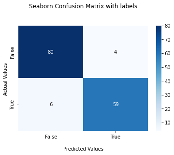

```python
y_pred = gnb.predict(x_test)

cf_matrix = metrics.confusion_matrix(y_test, y_pred)
cf_matrix

ax = sns.heatmap(cf_matrix, annot=True, cmap='Blues')

ax.set_title('Seaborn Confusion Matrix with labels\n\n');
ax.set_xlabel('\nPredicted Values')
ax.set_ylabel('Actual Values ');

## Ticket labels - List must be in alphabetical order
ax.xaxis.set_ticklabels(['False','True'])
ax.yaxis.set_ticklabels(['False','True'])

## Display the visualization of the Confusion Matrix.
plt.show()
```

Se puede observar que el clasificador Naive Bayes tiene un desempeño bastante sobresaliente, en las tres metricas escogidas.

```python
print("Accuracy:",metrics.accuracy_score(y_test, y_pred))
print("Precision:",metrics.precision_score(y_test, y_pred))
print("Recall:",metrics.recall_score(y_test, y_pred))
```

```
Accuracy: 0.9328859060402684
Precision: 0.9365079365079365
Recall: 0.9076923076923077
```

### K vecinos mas cercanos.

Es un método que simplemente busca en las observaciones más cercanas a la que se está tratando de predecir y clasifica el punto de interés basado en la mayoría de datos que le rodean.

```python
from sklearn.neighbors import KNeighborsClassifier

knn = KNeighborsClassifier()

k_range = list(range(1, 30))
param_grid = dict(n_neighbors=k_range)


knn_gv = GridSearchCV(knn, param_grid, cv=5, scoring='accuracy')

# fitting the model for grid search
knn_gv.fit(x_train, y_train)
```

```
GridSearchCV(cv=5, estimator=KNeighborsClassifier(),
             param_grid={'n_neighbors': [1, 2, 3, 4, 5, 6, 7, 8, 9, 10, 11, 12,
                                         13, 14, 15, 16, 17, 18, 19, 20, 21, 22,
                                         23, 24, 25, 26, 27, 28, 29]},
             scoring='accuracy')
```

```python
knn_gv.best_params_
# {'n_neighbors': 3}
```

```
{'n_neighbors': 1}
```

[figure not shown]

```python
y_pred = knn_gv.predict(x_test)

cf_matrix = metrics.confusion_matrix(y_test, y_pred)
cf_matrix

ax = sns.heatmap(cf_matrix, annot=True, cmap='Blues')

ax.set_title('Seaborn Confusion Matrix with labels\n\n');
ax.set_xlabel('\nPredicted Values')
ax.set_ylabel('Actual Values ');

## Ticket labels - List must be in alphabetical order
ax.xaxis.set_ticklabels(['False','True'])
ax.yaxis.set_ticklabels(['False','True'])

## Display the visualization of the Confusion Matrix.
plt.show()
```

Se puede observar que el metodo de KNN tambien tiene un muy buen desempeño.

```python
print("Accuracy:",metrics.accuracy_score(y_test, y_pred))
print("Precision:",metrics.precision_score(y_test, y_pred))
print("Recall:",metrics.recall_score(y_test, y_pred))
```

```
Accuracy: 0.8859060402684564
Precision: 0.9137931034482759
Recall: 0.8153846153846154
```

### Random Forest Classifier

Bosque aleatorio es uno de los algoritmos de aprendizaje supervisado basados en árboles más populares. También es el más flexible y fácil de usar.

```python
from sklearn.ensemble import RandomForestClassifier
rfc=RandomForestClassifier(random_state=semilla)

param_grid = {
    'n_estimators': [10,25,30,40,50,60,90],
    'max_features': ['auto', 'sqrt', 'log2'],
    'max_depth' : [2,3,4,5,6],
    'criterion' :['gini', 'entropy']
}

CV_rfc = GridSearchCV(estimator=rfc, param_grid=param_grid, cv= 5, scoring="accuracy")
CV_rfc.fit(x_train, y_train)
```

```
GridSearchCV(cv=5, estimator=RandomForestClassifier(random_state=123),
             param_grid={'criterion': ['gini', 'entropy'],
                         'max_depth': [2, 3, 4, 5, 6],
                         'max_features': ['auto', 'sqrt', 'log2'],
                         'n_estimators': [10, 25, 30, 40, 50, 60, 90]},
             scoring='accuracy')
```

```python
CV_rfc.best_params_
# {'criterion': 'gini',
#  'max_depth': 2,
#  'max_features': 'auto',
#  'n_estimators': 25}
```

```
{'criterion': 'gini',
 'max_depth': 2,
 'max_features': 'auto',
 'n_estimators': 25}
```

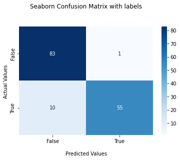

```python
y_pred = CV_rfc.predict(x_test)

cf_matrix = metrics.confusion_matrix(y_test, y_pred)
cf_matrix

ax = sns.heatmap(cf_matrix, annot=True, cmap='Blues')

ax.set_title('Seaborn Confusion Matrix with labels\n\n');
ax.set_xlabel('\nPredicted Values')
ax.set_ylabel('Actual Values ');

## Ticket labels - List must be in alphabetical order
ax.xaxis.set_ticklabels(['False','True'])
ax.yaxis.set_ticklabels(['False','True'])

## Display the visualization of the Confusion Matrix.
plt.show()
```

```python
print("Accuracy:",metrics.accuracy_score(y_test, y_pred))
print("Precision:",metrics.precision_score(y_test, y_pred))
print("Recall:",metrics.recall_score(y_test, y_pred))
```

```
Accuracy: 0.9261744966442953
Precision: 0.9821428571428571
Recall: 0.8461538461538461
```

### Evaluacion y comparacion.

Se puede observar los mejores modelos, de los cuales se destacan dos, que son **Random Forest** y **Naive Bayes**.

| Modelo | Accuracy | Precision | Recall |
| --- | --- | --- | --- |
| Regresion Logistica | 0.5637 | 0.0 | 0.0 |
| Naive Bayes | 0.932885 | 0.936507 | 0.907692 |
| KNN | 0.885906 | 0.913793 | 0.815384 |
| Random Forest | 0.926174 | 0.982142 | 0.846153 |

```python
# y_test = np.asarray(y_test)
# misclassified = np.where(y_test != knn_gv.predict(x_test))
# print(knn_gv.predict(x_test)[misclassified])
# print(y_test[misclassified])
```

### Clasificar imagenes y cargarlas a la carpeta correspondiente.

Se escogió como mejor modelo, el modelo Naive Bayes.

Con este modelo, se clasifica para todos los archivos, si tienen contenido o no tienen contenido. Posteriormente, se crear un ciclo, en el cual se verifica su clasificación, y si tiene contenido, la imagen (que esta en forma matricial almacenada en un diccionario de Python), se envía a la carpeta docs_con_contenido, y si esta clasificada que no tiene contenido, se envía a la carpeta docs_sin_contenido.

```python
real_y = pd.DataFrame(complete_df["texto"], index=complete_df.index)
real_y.columns = ["real"]
real_y["0_black"] = complete_df["0_black"]
real_y["0_white"] = complete_df["0_white"]
real_y['preds'] = gnb.predict(real_y[["0_black", "0_white"]])
real_y = real_y[["0_black", "0_white", "real","preds"]]
real_y.columns = ["0_black_y", "0_white_y", "real","preds"]
```

Una muestra de la clasificacion real, y la predicha.

```python
real_y
```

|  | 0_black_y | 0_white_y | real | preds |
| --- | --- | --- | --- | --- |
| 0 | 0 | 2267269 | 0 | 0 |
| 1 | 0 | 75999 | 0 | 0 |
| 2 | 0 | 17782 | 0 | 0 |
| 3 | 0 | 4572755 | 0 | 0 |
| 4 | 0 | 2042844 | 0 | 0 |
| ... | ... | ... | ... | ... |
| 242 | 9676 | 1889344 | 1 | 1 |
| 243 | 48253 | 1657757 | 1 | 1 |
| 244 | 8703 | 1875174 | 1 | 1 |
| 245 | 36835 | 1667108 | 1 | 1 |
| 246 | 30686 | 1806496 | 1 | 1 |

247 rows × 4 columns

Se agrega la base con los datos predichos, del modelo Naive Bayes, a la base de datos original. Esto para poder obtener el nombre de cada documento escaneado.

```python
final_df = pd.concat([complete_df, real_y], axis=1)
final_df
```

|  | level_0 | index | 0_black | 0_white | texto | 0_black_y | 0_white_y | real | preds |
| --- | --- | --- | --- | --- | --- | --- | --- | --- | --- |
| 0 | 0 | page-156 | 0 | 2267269 | 0 | 0 | 2267269 | 0 | 0 |
| 1 | 1 | page-157 | 0 | 75999 | 0 | 0 | 75999 | 0 | 0 |
| 2 | 2 | page-158 | 0 | 17782 | 0 | 0 | 17782 | 0 | 0 |
| 3 | 3 | page-159 | 0 | 4572755 | 0 | 0 | 4572755 | 0 | 0 |
| 4 | 4 | page-160 | 0 | 2042844 | 0 | 0 | 2042844 | 0 | 0 |
| ... | ... | ... | ... | ... | ... | ... | ... | ... | ... |
| 242 | 95 | page-89 | 9676 | 1889344 | 1 | 9676 | 1889344 | 1 | 1 |
| 243 | 96 | page-9 | 48253 | 1657757 | 1 | 48253 | 1657757 | 1 | 1 |
| 244 | 97 | page-92 | 8703 | 1875174 | 1 | 8703 | 1875174 | 1 | 1 |
| 245 | 98 | page-93 | 36835 | 1667108 | 1 | 36835 | 1667108 | 1 | 1 |
| 246 | 99 | page-94 | 30686 | 1806496 | 1 | 30686 | 1806496 | 1 | 1 |

247 rows × 9 columns

Aqui se pueden observar los archivos mas clasificados.

```python
final_df[final_df["real"]!=final_df["preds"]]
```

|  | level_0 | index | 0_black | 0_white | texto | 0_black_y | 0_white_y | real | preds |
| --- | --- | --- | --- | --- | --- | --- | --- | --- | --- |
| 15 | 15 | page-171 | 0 | 1720034 | 0 | 0 | 1720034 | 0 | 1 |
| 20 | 20 | page-176 | 0 | 1817838 | 0 | 0 | 1817838 | 0 | 1 |
| 45 | 45 | page-201 | 0 | 1831926 | 0 | 0 | 1831926 | 0 | 1 |
| 51 | 51 | page-207 | 0 | 1797015 | 0 | 0 | 1797015 | 0 | 1 |
| 63 | 63 | page-219 | 0 | 1742151 | 0 | 0 | 1742151 | 0 | 1 |
| 83 | 83 | page-239 | 0 | 1820990 | 0 | 0 | 1820990 | 0 | 1 |
| 88 | 88 | page-244 | 0 | 1673069 | 0 | 0 | 1673069 | 0 | 1 |
| 117 | 117 | page-273 | 0 | 1817838 | 0 | 0 | 1817838 | 0 | 1 |
| 151 | 4 | page-112 | 5645 | 1973359 | 1 | 5645 | 1973359 | 1 | 0 |
| 182 | 35 | page-16 | 15156 | 1099292 | 1 | 15156 | 1099292 | 1 | 0 |
| 194 | 47 | page-32 | 0 | 1612583 | 1 | 0 | 1612583 | 1 | 0 |
| 205 | 58 | page-45 | 0 | 361688 | 1 | 0 | 361688 | 1 | 0 |
| 216 | 69 | page-59 | 13372 | 1402840 | 1 | 13372 | 1402840 | 1 | 0 |
| 218 | 71 | page-60 | 2266 | 1985127 | 1 | 2266 | 1985127 | 1 | 0 |
| 233 | 86 | page-79 | 0 | 1588953 | 1 | 0 | 1588953 | 1 | 0 |

El diccionario con todos los archivos de inamgenes, en forma matricial.

```python
all_pages_dict =  {**dictionary_b,**dictionary_t}
all_pages_dict
```

[output not shown]

[output cut: 1674 more lines]

[output not shown]

Se tenian las imagenes en escala de grises, por lo cual, se cambia la imagen de escala de grises, a escala de color, para invertir el proceso.

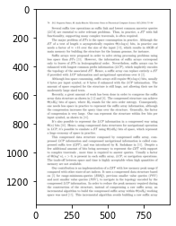

```python
fig = plt.figure()
plt.imshow(cv2.cvtColor(all_pages_dict["page-16"], cv2.COLOR_GRAY2RGB))
# plt.savefig('/tmp/test0.png')
# plt.close(fig)
plt.show()
```

Con todo lo anterior, se crea el ciclo, y se guardan los documentos dependiendo de su clasificacion.

```python
for i in np.arange(len(final_df["index"])):
    if final_df["preds"][i] == 1: # documentos con contenido tienen clasificacion 1
        fig = plt.figure()
        plt.imshow(cv2.cvtColor(all_pages_dict["{}".format(final_df["index"][i])], cv2.COLOR_GRAY2RGB))
        plt.savefig('./docs_con_contenido/{}.png'.format(final_df["index"][i]))
        plt.close(fig)
    else: # documentos sin contenido tienen clasificacion 0
        fig = plt.figure()
        plt.imshow(cv2.cvtColor(all_pages_dict["{}".format(final_df["index"][i])], cv2.COLOR_GRAY2RGB))
        plt.savefig('./docs_sin_contenido/{}.png'.format(final_df["index"][i]))
        plt.close(fig)
```